# PET575, Data Analysis in Python

*(Open in Playground mode. Shift+Enter runs a cell.)*

## What is Python?

- Python is a programmng language
- It is completely free
- It is the most popular language in Machine Learning and Data Analysis
- One of the most popular languages in general

## How is Python different?

##### No need to declare a type of variable:

```python
a = 5
b = 3.4
c = "test"

print("Variable 'a' is: " + str(type(a)))
print("Variable 'b' is: " + str(type(b)))
print("Variable 'c' is: " + str(type(c)))
```

```
Variable 'a' is: <class 'int'>
Variable 'b' is: <class 'float'>
Variable 'c' is: <class 'str'>
```

##### Function definitions and loops do not use brackets, only whitespace. This ensures that code looks tidy.

```python
def print_n_powers_of_2(n): #function definition
    for i in range(n):      #simple loop
        print(2**i)         #note that python starts counting at zero

print_n_powers_of_2(6)      #execute the function passing number 6 as parameter n
```

```
1
2
4
8
16
32
```

##### Python can be run in different ways:

- *notebook* - just like here
  - Required Anaconda installation (https://www.anaconda.com) - recommended
  - Online on Google Colaboratory (https://colab.research.google.com)
- .py file
  - Python3 is already installed on MacOS
  - Python3 is already installed on Linux
  - Python3 can installed on Windows through Anaconda (https://www.anaconda.com)

Note: Use Python 3.x only. Python 2.x also exists, but is being depreciated. For most intents and purposes Python 2 code will work in Python 3.

##### Working with notebooks

- memory state is not saved between sessions, but the output is
- cells can be executed out of sequence

```python
a = a + 1  #add one to a defined earlier. Re-running this cell will keep incrementing a
print (a)
```

```
6
```

##### Why Python over Matlab?

- Python has much higher adoption in the industry
- Python pushes out MATLAB in academia too
- Python is **free**, MATLAB is very much not. Many companies simply do not, and will not, own a MATLAB license.

Note: Python is very distributed in nature compared to compact package of MATLAB. If you are searching for funciton - use your search engine of choice: Google/DuckDuckGo/Qwant

## Python basics

### Defining variables

Below are some basic examples of variable definition

```python
a = 5        #python automatically knows if it is int, float, str, etc
b = "rabbit" #strings (text) comes in quote marks
c = a + 2    #you can do operations at the same time as definition
```

### Printing output

*Printing* is the basic way of showing data in Python. It is very forgiving.

```python
print(a)
print(b)
print(c+a)
```

```
5
rabbit
12
```

### Lists, NumPy

Lists, arrays, matrices - a sequence of variables

```python
a = [0, 1, 2, 3]
print(a)
```

```
[0, 1, 2, 3]
```

```python
a = [1, "two", 3.0] #feel free to mix types
print(type(a))
print()
print(type(a[0]))
print(type(a[1]))
print(type(a[2]))
```

```
<class 'list'>

<class 'int'>
<class 'str'>
<class 'float'>
```

To work on such data structures, the best is to use a library called **numpy**.

```python
import numpy as np
```

```python
a = [0, 1, 2, 3]
a = np.asarray(a) #convert python list to a numpy array
print(a)          #note the different printing format than before
```

```
[0 1 2 3]
```

This allows us to do different operations easily:

```python
print(a+2)
```

```
[2 3 4 5]
```

```python
print(a*2)
```

```
[0 2 4 6]
```

```python
b = np.asarray([5,6,5,6])
print(a)
print("    +")
print(b)
print("    =")

print(a+b)
```

```
[0 1 2 3]
    +
[5 6 5 6]
    =
[5 7 7 9]
```

#### Slices

To get a part of an array, slices are used.

```python
print(f'This is a complete array,                    a:{a}')
print(f'This is a a single element in an array,   a[2]:{a[2]}')
print(f'This is a slice of an array,            a[0:2]:{a[0:2]}') #note that slice is [inclisive:exclusive]
print(f'This is a last element of an array,      a[-1]:{a[-1]}')
```

```
This is a complete array,                    a:[0 1 2 3]
This is a a single element in an array,   a[2]:2
This is a slice of an array,            a[0:2]:[0 1]
This is a last element of an array,      a[-1]:3
```

Arrays can be nested

```python
#defining a nested list
a = [
    [1,2,3,4],
    [5,6,7,8]
    ]
```

**Caution**: Python lists behave differently than numpy arrays!

```python
print(a[0][1])
```

```
2
```

Notice different notation when converted to numpy array

```python
a = np.asarray(a)
print(a[0,1])
```

```
2
```

Slices are particularly useful here

```python
print(a[1,1:3])
```

```
[6 7]
```

### CAUTION!

Lists and arrays behave differently than variables.

```python
a = 2
b = a
b = b + 2

print(f'a is equal to {a}')
print(f'b is equal to {b}')
```

```
a is equal to 2
b is equal to 4
```

**But**, if we do the same thing with lists:

```python
a = [1,1,1,1,1]
b = a
b[1] = 3

print(f'List a looks like this: {a}')
print(f'List b looks like this: {b}')
```

```
List a looks like this: [1, 3, 1, 1, 1]
List b looks like this: [1, 3, 1, 1, 1]
```

Notice that list **a** also changed. Let's see how numpy arrays behave:

```python
a = np.asarray([1,1,1,1,1])
b = a
b[1] = 3

print(f'Numpy array a looks like this: {a}')
print(f'Numpy array b looks like this: {b}')
```

```
Numpy array a looks like this: [1 3 1 1 1]
Numpy array b looks like this: [1 3 1 1 1]
```

Same thing. There may be differences though:

```python
a = [1,1,1,1,1]
b = a[1:3]
b[1] = 3

print(f'List a looks like this: {a}')
print(f'List b looks like this: {b}')

a = np.asarray([1,1,1,1,1])
b = a[1:3]
b[1] = 3

print(f'Numpy array a looks like this: {a}')
print(f'Numpy array b looks like this: {b}')
```

```
List a looks like this: [1, 1, 1, 1, 1]
List b looks like this: [1, 3]
Numpy array a looks like this: [1 1 3 1 1]
Numpy array b looks like this: [1 3]
```

When using a *slice* **list** created a copy, but **numpy array** kept the reference.

Numpy can make a copy of an array if you are explicit about it

```python
a = np.asarray([1,1,1,1,1])
b = np.copy(a)
b[1] = 3

print(f'Numpy array a looks like this: {a}')
print(f'Numpy array b looks like this: {b}')
```

```
Numpy array a looks like this: [1 1 1 1 1]
Numpy array b looks like this: [1 3 1 1 1]
```

### NumPy continued

##### Let's generate some random numbers

**NOTE: you are NOT to memorize functions, use Google/DuckDuckGo/Qwant!**

https://docs.scipy.org/doc/numpy-1.15.0/reference/generated/numpy.random.normal.html

```python
a = np.random.normal(10, 2, 100) #center, std, size
print(a)
```

```
[ 7.6240235  11.76280582  9.01762748 10.42444908  8.37928248 11.9039274
  9.63897752  9.30555676 13.91692845  8.70449799 12.65109028  7.11773653
 10.76471188  6.97133693 10.56894209  9.63599316  7.45851747 10.12269343
 11.83791389  8.18845118 10.46332721  9.33313022 10.30906221  9.36794416
  9.11778192 10.05807366 10.93251319 11.02177274  9.87430969  9.10077282
 11.97647627 10.87875783 12.90546025  6.75260154 11.73262604  7.40087435
  8.86020838  7.66627408 10.65263508 11.7352162  12.15964735  9.09293901
 10.21105915  9.99854962  9.62507197 12.35789567  6.41393447  9.15983168
  7.58104186  9.5203138   8.36059366 13.50784819 10.67476131  8.9913917
  8.62791446  9.93447487  9.43521536  6.78106859 13.76038286  8.1894918
  8.84594017 12.62527636 11.04222497 13.17259629  9.34019203  8.43976763
  8.96223989 10.71134532 11.13620578  8.53631264 14.36170845  8.9480509
 12.2032383   7.85834879 11.11436957 11.50781356 11.65684675 10.15723462
 11.39501347  9.48313993 10.1582522   9.67430299  9.61059347 14.54208797
  5.57595916  8.82337766  7.66922658 10.1213115   4.98167652  6.70006533
 10.00018063 13.00862328 12.63482425 11.05492175 13.54941216  9.53367974
  8.81358687 10.18805671  7.24579629 10.5156783 ]
```

Numpy allows us to quickly calculate many attributes of a given array

```python
a_max = a.max()
print(f'The maximum value is {a_max}') #note the f notation
print(f'The minimum value is {a.min()}') #we can do more in the curly brackets too
print(f'The sum is {a.sum()}')
print(f'The average is {a.mean()}')
print(f'The standard deviation is {a.std()}')
```

```
The maximum value is 14.542087965625658
The minimum value is 4.981676524063535
The sum is 996.4181873140388
The average is 9.964181873140388
The standard deviation is 1.9644008543827691
```

To avoid too many decimals, we can simply round the numbers

```python
np.round(a.std(),2)
```

```
1.96
```

### Functions

Functions work the same way as in most other programming languages

```python
def a_to_b(a,b):
    return(a**b)

print(a_to_b(3,4))
```

```
81
```

### Conditional statements

same as functions. Remember dual equal signs!

```python
def even_odd(a):
    if a%2 == 0:    #Percentage symbol is modulo. Here divide by 2 and return the rest
        print(f'{a} is even')
    else:
        print(f'{a} is odd')

even_odd(3)
even_odd(4)
```

```
3 is odd
4 is even
```

### Loops

#### for

for loop can be used in a number of ways

```python
for i in range(4):
    print(i)
```

```
0
1
2
3
```

```python
for i in range(4,10):
    print(i)
```

```
4
5
6
7
8
9
```

```python
text = "rabbit"
for i in text:
    print(i)
```

```
r
a
b
b
i
t
```

```python
some_numbers = np.random.normal(1,1,10)
for i in some_numbers:
    print(np.round(i,2))
```

```
-0.3
1.29
-0.21
-0.62
0.26
2.04
1.48
0.89
0.16
1.46
```

## Excercise 1

You are playing a simple board game. You roll a dice and advance forward by the number of dots. Easy.

Some fields are special. Some are *You wait one round* or *You roll again*.

One field is *very* special. The rules state:

- roll dice 3 times
- you move forward by the two lowest numbers
- you move back by the highest number

Example: you roll 2, 6 and 4. You move forwards by 2 + 4 and move backwards by 6

**Question:** Is it a good, or a bad field? What is the mean and median result?

```python
def monte_carlo(rolls):

    results = []   #initiate an empty list

    for i in range(rolls):  #Perform given number of simulations
        sample = np.random.randint(1,7,3) #Return random integers from low (inclusive) to high (exclusive).
        sample = np.sort(sample) #sort the values ascending
        results.append(sample[0]+sample[1]-sample[2])  #apply the rule and append it to the list

    return(results)  #return the results
```

Execute the simulation. You can see how increasing the amount of iterations increases the calculation time

```python
a = monte_carlo(10000)
```

Print requested values

```python
print(f'The mean movement was {np.mean(a)}')
print(f'The median movement was {np.median(a)}')
print(f'Achieved values are {np.unique(a)}')
```

```
The mean movement was 0.5754
The median movement was 1.0
Achieved values are [-4 -3 -2 -1  0  1  2  3  4  5  6]
```

### Data visualization

For making of various charts **MatPlotLib** is the most popular library. It has a similar syntax to MATLAB.

**Seaborn** is an add-on to **MatPlotLib** that makes generating more complex charts easier.

First, let's import the libraries:

```python
import matplotlib.pyplot as plt #matplotlib is the most common plotting library for Python.
import seaborn as sns   #seaborn is an extension to matplotlib


sns.set() #this function call sets some defaults to seaborn's defaults.
```

Let's plot a distribution plot

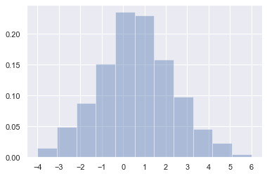

```python
bins = len(np.unique(a))    #define variable "bins" by counting how many unique values there were in the simulation
sns.distplot(a, bins = bins, hist=True, kde=False, norm_hist=True) #make a histogram
plt.xticks(np.unique(a))    #defining which ticks should be plotted on x axis
plt.show()     #call to show the plot. Note that we mixed seaborn and matplotlib functions.
```

Experiment on your own: Does it make a difference how many sides does the dice have?

### More visualization

Let's generate some data to plot

```python
n = 10000
theta = np.random.normal(np.pi*3/4, 1, n)  #random numbers with normal distribution, centered at 3/4 pi
noise_x = np.random.normal(0,0.2,n) #generating numpy arrays with noise
noise_y = np.random.normal(0,0.2,n)
x = np.sin(theta)+noise_x #calculating x coordinate
y = np.cos(theta)+noise_y #calculating y coordinate
```

We can plot the data as a **joint plot** with **hex plot** in the middle. This is very convinient for showing density data.

Seaborn makes creating such relatively complex charts very easy.

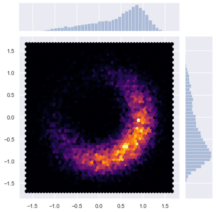

```python
sns.jointplot(x, y, kind="hex", gridsize=50, cmap="inferno")
```

Alternatively we can use **kernel density estimate** for a smooth plot.

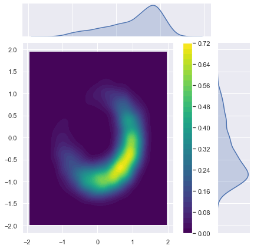

```python
sns.jointplot(x=x, y=y, kind="kde",n_levels=35, cmap="viridis", cbar=True)
```

Some plots can be combined. Note slightly different notation for generating the plot.

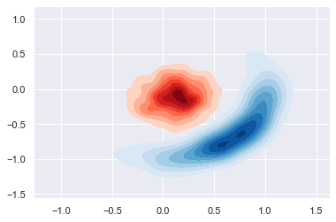

```python
n = 1000
theta = np.random.normal(np.pi*3/4, 0.6, n)
noise_x = np.random.normal(0,0.1,n)
noise_y = np.random.normal(0,0.1,n)
x = np.sin(theta)+noise_x
y = np.cos(theta)+noise_y

noise_v = np.random.normal(0,0.2,n)
noise_w = np.random.normal(0,0.2,n)
v = np.sin(theta)*0.2+noise_v
w = np.cos(theta)*0.2+noise_w


ax = sns.kdeplot(x, y, shade=True, cmap="Blues", shade_lowest=False)
ax = sns.kdeplot(v, w, shade=True, cmap="Reds", shade_lowest=False)
```

### Line plot, scatter plot

```python
n = 100
x = np.linspace(0,10,n) #create an array that starts at 0, ends at 10 and has n evenly spaced elements
y = np.sin(x)
```

Very simple plotting with just MatPlotLib

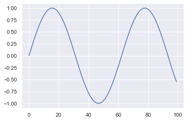

```python
plt.plot(y)
```

Seaborn requires two parameters. Notice x axis ticks. In the example above they correspond to the index of the numpy array.

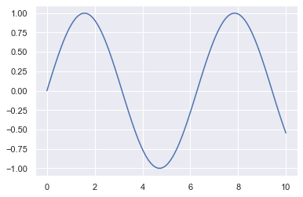

```python
sns.lineplot(x,y)
```

Best practice is to specify both axis, see example why:

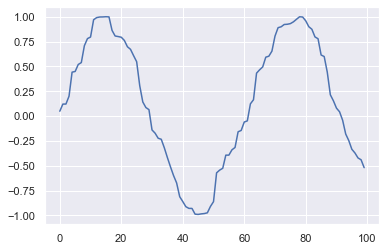

```python
x = np.random.uniform(0,10,n)   #create an array with random, uniform distribution
                                #between 0 and 10
x = np.sort(x)                  #sort. This is now an unevenly polled domain

y = np.sin(x)

plt.plot(y)
```

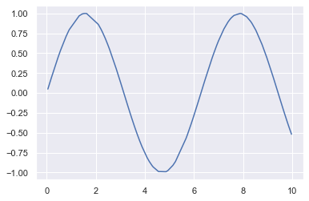

```python
plt.plot(x,y)
```

The first chart is distorted due to uneven polling, even though the signal is perfectly noise free. When specified x and y variables, the signal is now plotted correctly

### Scatter plots

Very similar to line plots, work better with noisy data

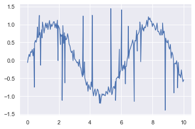

```python
n = 200
x = np.linspace(0,10,n) #create an array that starts at 0, ends at 10 and has n evenly spaced elements
y = np.sin(x)+np.random.normal(0,0.1,n)

outlier_x = np.random.uniform(0,10,30)
outlier_y = np.random.uniform(-1.5, 1.5, 30)

x = np.append(x, outlier_x)
y = np.append(y, outlier_y)

sns.lineplot(x,y)
```

Line plot looks very bad, compare with scatter plot

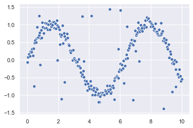

```python
sns.scatterplot(x,y)
```

One can plot multiple plots at the same time

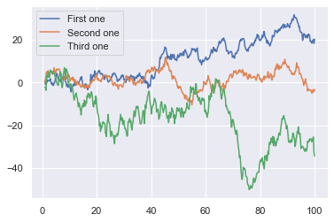

```python
n = 500
x = np.linspace(1,100,n)
y1 = np.cumsum(np.random.normal(0,1,n))
y2 = np.cumsum(np.random.normal(-0.1,1,n))
y3 = np.cumsum(np.random.normal(0,2,n))

sns.lineplot(x,y1, label="First one")
sns.lineplot(x,y2, label="Second one")
sns.lineplot(x,y3, label="Third one")
```

### Other plot types

There are many more plot types, see documentation for MatPlotLib and Seaborn for more information

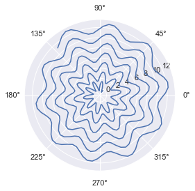

```python
n = 500
x = np.linspace(1,40,n)
y = 0.3*x+np.sin(x*10)

plt.polar(x,y)
```

# Pandas

Pandas is an extremely popular package in data science. In short, it deals with 2D arrays called **dataframes** and has a plethora of data science functions.

Let's start by exploring the Titanic dataset

```python
import numpy as np  #import numpy
import pandas as pd  #import pandas
import seaborn as sns #import seaborn
import matplotlib.pyplot as plt #import matplotlib
df = sns.load_dataset('titanic') #load the titanic dataset to a pandas dataframe
sns.set() #seaborn's defaults
```

It is very simple to look around the dataframe. Use .head() to view 5 top rows. You can also use .head(*a*) for defined number of rows.

```python
df.head()
```

|  | survived | pclass | sex | age | sibsp | parch | fare | embarked | class | who | adult_male | deck | embark_town | alive | alone |
| --- | --- | --- | --- | --- | --- | --- | --- | --- | --- | --- | --- | --- | --- | --- | --- |
| 0 | 0 | 3 | male | 22.0 | 1 | 0 | 7.2500 | S | Third | man | True | NaN | Southampton | no | False |
| 1 | 1 | 1 | female | 38.0 | 1 | 0 | 71.2833 | C | First | woman | False | C | Cherbourg | yes | False |
| 2 | 1 | 3 | female | 26.0 | 0 | 0 | 7.9250 | S | Third | woman | False | NaN | Southampton | yes | True |
| 3 | 1 | 1 | female | 35.0 | 1 | 0 | 53.1000 | S | First | woman | False | C | Southampton | yes | False |
| 4 | 0 | 3 | male | 35.0 | 0 | 0 | 8.0500 | S | Third | man | True | NaN | Southampton | no | True |

.describe() returns basic statistical data for each column

```python
df.describe()
```

|  | survived | pclass | age | sibsp | parch | fare |
| --- | --- | --- | --- | --- | --- | --- |
| count | 891.000000 | 891.000000 | 714.000000 | 891.000000 | 891.000000 | 891.000000 |
| mean | 0.383838 | 2.308642 | 29.699118 | 0.523008 | 0.381594 | 32.204208 |
| std | 0.486592 | 0.836071 | 14.526497 | 1.102743 | 0.806057 | 49.693429 |
| min | 0.000000 | 1.000000 | 0.420000 | 0.000000 | 0.000000 | 0.000000 |
| 25% | 0.000000 | 2.000000 | 20.125000 | 0.000000 | 0.000000 | 7.910400 |
| 50% | 0.000000 | 3.000000 | 28.000000 | 0.000000 | 0.000000 | 14.454200 |
| 75% | 1.000000 | 3.000000 | 38.000000 | 1.000000 | 0.000000 | 31.000000 |
| max | 1.000000 | 3.000000 | 80.000000 | 8.000000 | 6.000000 | 512.329200 |

To get a list of all the attributes in a dataset call list(df).

```python
list(df)
```

```
['survived',
 'pclass',
 'sex',
 'age',
 'sibsp',
 'parch',
 'fare',
 'embarked',
 'class',
 'who',
 'adult_male',
 'deck',
 'embark_town',
 'alive',
 'alone']
```

**Sorting.**

It is sometimes convinient to sort the DataFrame by an attribute. Note that in example below the original dataframe remains untouched (unsorted).

```python
df.sort_values(by="age").head(15)
```

|  | survived | pclass | sex | age | sibsp | parch | fare | embarked | class | who | adult_male | deck | embark_town | alive | alone |
| --- | --- | --- | --- | --- | --- | --- | --- | --- | --- | --- | --- | --- | --- | --- | --- |
| 803 | 1 | 3 | male | 0.42 | 0 | 1 | 8.5167 | C | Third | child | False | NaN | Cherbourg | yes | False |
| 755 | 1 | 2 | male | 0.67 | 1 | 1 | 14.5000 | S | Second | child | False | NaN | Southampton | yes | False |
| 644 | 1 | 3 | female | 0.75 | 2 | 1 | 19.2583 | C | Third | child | False | NaN | Cherbourg | yes | False |
| 469 | 1 | 3 | female | 0.75 | 2 | 1 | 19.2583 | C | Third | child | False | NaN | Cherbourg | yes | False |
| 78 | 1 | 2 | male | 0.83 | 0 | 2 | 29.0000 | S | Second | child | False | NaN | Southampton | yes | False |
| 831 | 1 | 2 | male | 0.83 | 1 | 1 | 18.7500 | S | Second | child | False | NaN | Southampton | yes | False |
| 305 | 1 | 1 | male | 0.92 | 1 | 2 | 151.5500 | S | First | child | False | C | Southampton | yes | False |
| 827 | 1 | 2 | male | 1.00 | 0 | 2 | 37.0042 | C | Second | child | False | NaN | Cherbourg | yes | False |
| 381 | 1 | 3 | female | 1.00 | 0 | 2 | 15.7417 | C | Third | child | False | NaN | Cherbourg | yes | False |
| 164 | 0 | 3 | male | 1.00 | 4 | 1 | 39.6875 | S | Third | child | False | NaN | Southampton | no | False |
| 183 | 1 | 2 | male | 1.00 | 2 | 1 | 39.0000 | S | Second | child | False | F | Southampton | yes | False |
| 386 | 0 | 3 | male | 1.00 | 5 | 2 | 46.9000 | S | Third | child | False | NaN | Southampton | no | False |
| 172 | 1 | 3 | female | 1.00 | 1 | 1 | 11.1333 | S | Third | child | False | NaN | Southampton | yes | False |
| 788 | 1 | 3 | male | 1.00 | 1 | 2 | 20.5750 | S | Third | child | False | NaN | Southampton | yes | False |
| 642 | 0 | 3 | female | 2.00 | 3 | 2 | 27.9000 | S | Third | child | False | NaN | Southampton | no | False |

To check who is the oldest on Titanic, sort descending. Note additional .dropna() that drops the lines containing missing values.

```python
df.dropna().sort_values(by="age", ascending=False).head(15)
```

|  | survived | pclass | sex | age | sibsp | parch | fare | embarked | class | who | adult_male | deck | embark_town | alive | alone |
| --- | --- | --- | --- | --- | --- | --- | --- | --- | --- | --- | --- | --- | --- | --- | --- |
| 630 | 1 | 1 | male | 80.0 | 0 | 0 | 30.0000 | S | First | man | True | A | Southampton | yes | True |
| 96 | 0 | 1 | male | 71.0 | 0 | 0 | 34.6542 | C | First | man | True | A | Cherbourg | no | True |
| 745 | 0 | 1 | male | 70.0 | 1 | 1 | 71.0000 | S | First | man | True | B | Southampton | no | False |
| 54 | 0 | 1 | male | 65.0 | 0 | 1 | 61.9792 | C | First | man | True | B | Cherbourg | no | False |
| 456 | 0 | 1 | male | 65.0 | 0 | 0 | 26.5500 | S | First | man | True | E | Southampton | no | True |
| 438 | 0 | 1 | male | 64.0 | 1 | 4 | 263.0000 | S | First | man | True | C | Southampton | no | False |
| 275 | 1 | 1 | female | 63.0 | 1 | 0 | 77.9583 | S | First | woman | False | D | Southampton | yes | False |
| 252 | 0 | 1 | male | 62.0 | 0 | 0 | 26.5500 | S | First | man | True | C | Southampton | no | True |
| 625 | 0 | 1 | male | 61.0 | 0 | 0 | 32.3208 | S | First | man | True | D | Southampton | no | True |
| 170 | 0 | 1 | male | 61.0 | 0 | 0 | 33.5000 | S | First | man | True | B | Southampton | no | True |
| 587 | 1 | 1 | male | 60.0 | 1 | 1 | 79.2000 | C | First | man | True | B | Cherbourg | yes | False |
| 366 | 1 | 1 | female | 60.0 | 1 | 0 | 75.2500 | C | First | woman | False | D | Cherbourg | yes | False |
| 11 | 1 | 1 | female | 58.0 | 0 | 0 | 26.5500 | S | First | woman | False | C | Southampton | yes | True |
| 487 | 0 | 1 | male | 58.0 | 0 | 0 | 29.7000 | C | First | man | True | B | Cherbourg | no | True |
| 268 | 1 | 1 | female | 58.0 | 0 | 1 | 153.4625 | S | First | woman | False | C | Southampton | yes | False |

To drop NaN existing only in the age column, more complex operation is necessary.

Notice that we got more results - the deck attribute is full of NaNs

```python
df2 = df[np.isfinite(df['age'])]                        #create a new dataframe, that is a copy of df where df['age']
                                                        #is finite, ie. is not NaN or inf
                                                        #Note! This is a reference, not a copy!
df2.sort_values(by="age", ascending=False).head(15)
```

|  | survived | pclass | sex | age | sibsp | parch | fare | embarked | class | who | adult_male | deck | embark_town | alive | alone |
| --- | --- | --- | --- | --- | --- | --- | --- | --- | --- | --- | --- | --- | --- | --- | --- |
| 630 | 1 | 1 | male | 80.0 | 0 | 0 | 30.0000 | S | First | man | True | A | Southampton | yes | True |
| 851 | 0 | 3 | male | 74.0 | 0 | 0 | 7.7750 | S | Third | man | True | NaN | Southampton | no | True |
| 493 | 0 | 1 | male | 71.0 | 0 | 0 | 49.5042 | C | First | man | True | NaN | Cherbourg | no | True |
| 96 | 0 | 1 | male | 71.0 | 0 | 0 | 34.6542 | C | First | man | True | A | Cherbourg | no | True |
| 116 | 0 | 3 | male | 70.5 | 0 | 0 | 7.7500 | Q | Third | man | True | NaN | Queenstown | no | True |
| 672 | 0 | 2 | male | 70.0 | 0 | 0 | 10.5000 | S | Second | man | True | NaN | Southampton | no | True |
| 745 | 0 | 1 | male | 70.0 | 1 | 1 | 71.0000 | S | First | man | True | B | Southampton | no | False |
| 33 | 0 | 2 | male | 66.0 | 0 | 0 | 10.5000 | S | Second | man | True | NaN | Southampton | no | True |
| 54 | 0 | 1 | male | 65.0 | 0 | 1 | 61.9792 | C | First | man | True | B | Cherbourg | no | False |
| 280 | 0 | 3 | male | 65.0 | 0 | 0 | 7.7500 | Q | Third | man | True | NaN | Queenstown | no | True |
| 456 | 0 | 1 | male | 65.0 | 0 | 0 | 26.5500 | S | First | man | True | E | Southampton | no | True |
| 438 | 0 | 1 | male | 64.0 | 1 | 4 | 263.0000 | S | First | man | True | C | Southampton | no | False |
| 545 | 0 | 1 | male | 64.0 | 0 | 0 | 26.0000 | S | First | man | True | NaN | Southampton | no | True |
| 275 | 1 | 1 | female | 63.0 | 1 | 0 | 77.9583 | S | First | woman | False | D | Southampton | yes | False |
| 483 | 1 | 3 | female | 63.0 | 0 | 0 | 9.5875 | S | Third | woman | False | NaN | Southampton | yes | True |

We can quickly analyse the age distribution among the passangers

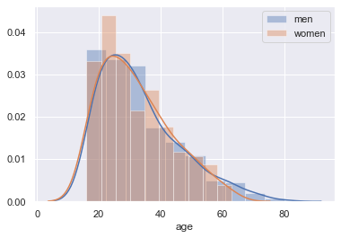

```python
df = df[np.isfinite(df['age'])]                                                 #get only results with finite age
sns.distplot(df[df['who'] == "man"]['age'], bins=10, hist=True, label="men")    #histogram of men
sns.distplot(df[df['who'] == "woman"]['age'], bins=10, hist=True, label="women")#histogram of women
plt.legend()                                                                    #add a legend to chart
```

We can also quickly show how that distribution is when split into different classes.

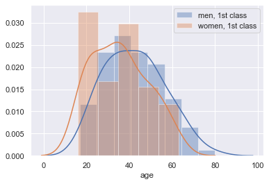

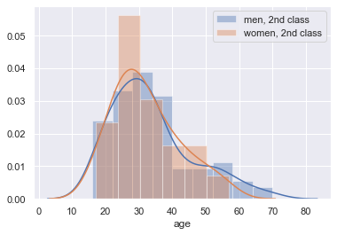

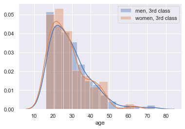

```python
df1 = df[df['class']=="First"]      #defining sub-dataframes containing only passengers of first/second/third class
df2 = df[df['class']=="Second"]
df3 = df[df['class']=="Third"]

sns.distplot(df1[df1['who'] == "man"]['age'], hist=True, label="men, 1st class")
sns.distplot(df1[df1['who'] == "woman"]['age'], hist=True, label="women, 1st class")
plt.legend()
plt.show()               #necessary to show the chart. If we ommit this, we will have everything in one chart.

sns.distplot(df2[df2['who'] == "man"]['age'], hist=True, label="men, 2nd class")
sns.distplot(df2[df2['who'] == "woman"]['age'], hist=True, label="women, 2nd class")
plt.legend()
plt.show()

sns.distplot(df3[df3['who'] == "man"]['age'], hist=True, label="men, 3rd class")
sns.distplot(df3[df3['who'] == "woman"]['age'], hist=True, label="women, 3rd class")
plt.legend()
plt.show()
```

Things to notice:

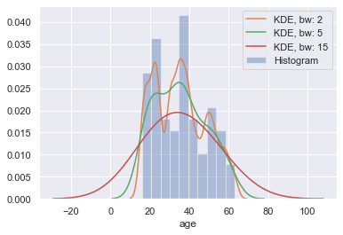

```python
sns.distplot(df1[df1['who'] == "woman"]['age'], bins= 10, hist=True, kde=False, norm_hist=True, label="Histogram")

sns.distplot(df1[df1['who'] == "woman"]['age'], hist=False, label="KDE, bw: 2",
             kde_kws={'gridsize' : 100, "bw" : 2})

sns.distplot(df1[df1['who'] == "woman"]['age'], hist=False, label="KDE, bw: 5",
             kde_kws={'gridsize' : 100, "bw" : 5})

sns.distplot(df1[df1['who'] == "woman"]['age'], hist=False, label="KDE, bw: 15",
             kde_kws={'gridsize' : 100, "bw" : 15})

plt.legend()
```

### Why not simply Excel?

Prep takes longer, but reuse is **much** faster with Python.

Let's load weather data from Lerwick weather station (Shetland Islands, Scotland).

```python
df = pd.read_csv("http://www.ux.uis.no/~atunkiel/lerwickdata.csv", delim_whitespace=True)
                                                                #delim_whitespace - whitespace separated file
                #notice that we read csv straight from a website

#year and month are separate in this dataset. Let's merge it and tell pandas that it is a date.
df["date"] = df["mm"].map(str) + "." +df["yyyy"].map(str)
df['date'] = pd.to_datetime(df['date'],format = '%m.%Y')
```

Quick inspection of the dataframe

```python
df.head()
```

|  | yyyy | mm | tmax[degC] | tmin[degC] | af[days] | rain[mm] | sun[hours] | date |
| --- | --- | --- | --- | --- | --- | --- | --- | --- |
| 0 | 1930 | 12 | 7.0 | 3.6 | 0 | 122.4 | 13.1 | 1930-12-01 |
| 1 | 1931 | 1 | 4.9 | 0.2 | 13 | 108.0 | 29.7 | 1931-01-01 |
| 2 | 1931 | 2 | 4.4 | -0.3 | 12 | 138.3 | 52.6 | 1931-02-01 |
| 3 | 1931 | 3 | 4.2 | -1.0 | 17 | 18.2 | 135.7 | 1931-03-01 |
| 4 | 1931 | 4 | 8.1 | 2.5 | 1 | 70.9 | 134.7 | 1931-04-01 |

Let's inspect the maximum recorded temperatures

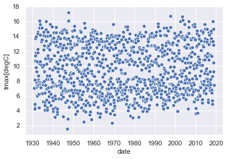

```python
sns.scatterplot(df['date'],df['tmax[degC]'])
```

Let's do some rolling average to have a cleaner look at data.

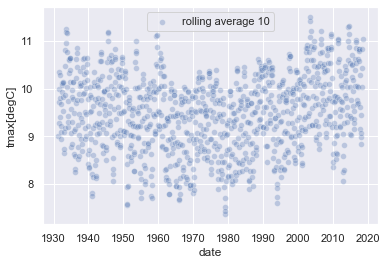

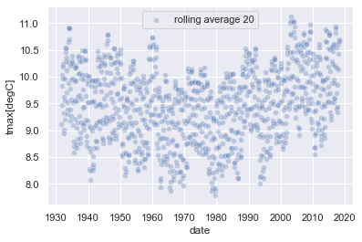

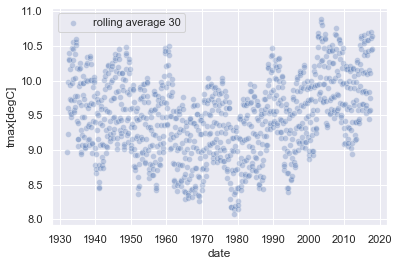

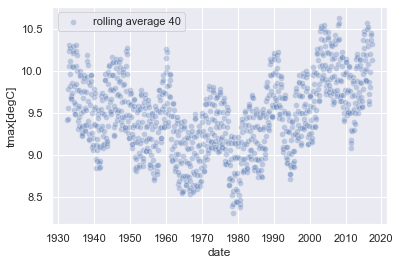

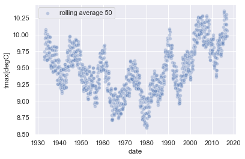

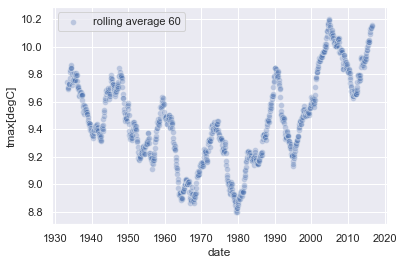

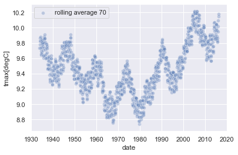

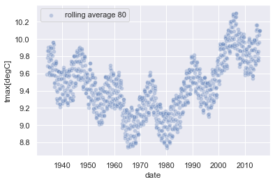

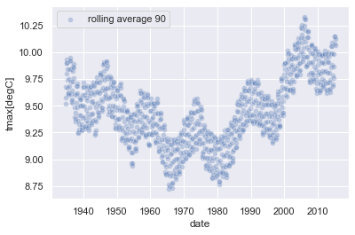

```python
for i in range(1,10):
    sns.scatterplot(df['date'],df['tmax[degC]'].rolling(10*i).mean(center=True),
                    alpha=0.3, label=f'rolling average {10*i}')
    plt.show()
```

It seems that window of 60 gives the best results. Why 60? Probably because there are 12 months in a year and 60 divides nicely by 12.